# CIA III: Dynamic Price Elasticity Framework

# Visualisation Code snippet

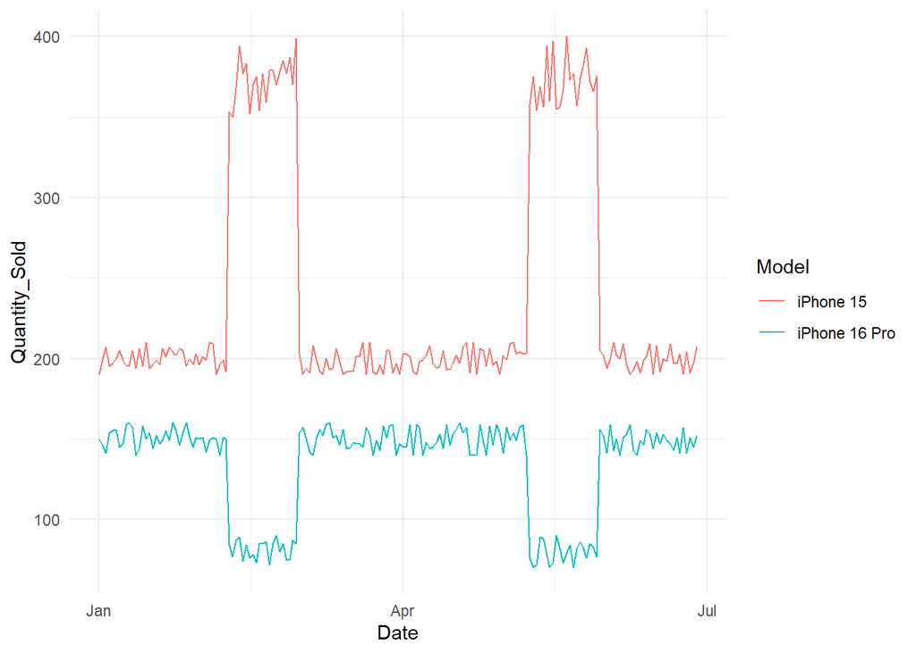

```r
# Time-series line chart: daily Quantity_Sold for both models across the full dataset
# Color aesthetic distinguishes iPhone 15 from iPhone 16 Pro, revealing divergence
# patterns during promotional windows
ggplot(sales_data, aes(Date, Quantity_Sold, color = Model)) +
  geom_line() +
  theme_minimal()
```

# Conclusion and Managerial Implications

## Final Analysis Conclusion

The R-based framework identifies a consistent pattern of cross-price cannibalisation between the iPhone 15 and iPhone 16 Pro across both the Valentine’s and Summer promotional events.

The computed positive cross-price elasticity confirms that the two models function as substitute goods within the same product ecosystem. The Interrupted Time-Series visualisation further validates this relationship by revealing a clear sales divergence pattern: promotional periods for the iPhone 15 correspond with a measurable decline in iPhone 16 Pro sales.

## Managerial Implications

Based on these findings, the following strategic actions are recommended:

**Shift from Price Cuts to Value-Based Positioning:** To protect premium product sales, firms should replace aggressive discounting with value-added bundling strategies for the iPhone 16 Pro. Bundles such as extended warranties (e.g., AppleCare+) or premium accessories can enhance perceived value without reducing the product’s price integrity.

**Promotion De-Confliction Strategy:** Simultaneous promotions across substitute products create internal competition. Managers should stagger promotional timing, ensuring that base-model clearance campaigns do not overlap with key marketing periods for premium models, thereby reducing customer trade-down behaviour.

**Continuous Elasticity Monitoring (DSS Implementation):** The developed R-based framework functions as a Decision Support System (DSS). By conducting rolling elasticity analysis on updated sales data, managers can dynamically anticipate cannibalisation risks and maximise overall category profitability rather than isolated product volume.

## Final Insight

The analysis demonstrates that pricing decisions must be evaluated at the portfolio level, not the individual product level. Without such a structured framework, short-term volume gains may conceal long-term profitability losses driven by internal demand shifts.

# Automated HTML Report Generation

```r
# Run this line to automatically knit the document and save the HTML directly to your Downloads folder
rmarkdown::render("Your_File_Name.Rmd", output_file = "C:/Users/alexa/Downloads/CIA-R.html")
```